# SRP058181

Regina H. Reynolds

UCL

> Aim: to format SRP058181, such that it can be used to validate (i) deconvolution and (ii) differentially spliced genes

# 1 File paths/files for workflow

```r
source(here::here("R", "file_paths.R"))

sample_info <-
  read_excel(
    path =
      file.path(
        path_to_raw_data,
        "sample_details/SRP058181_sample_metadata.xlsx")
  ) %>%
  dplyr::na_if(.,"N/A") %>%
  dplyr::select(-Proteomics, -Proteomics_SV1, -Proteomics_SV2, -Proteomics_SV3, -Microarray_study_ID) %>%
  dplyr::mutate(sample_id = `RNA-Seq_Samples`,
                Braak_score = Braak_score %>%
                  str_replace_all(c("IV" = "4",
                                    "II-III" = "3",
                                    "I-II" = "2",
                                    "III" = "3",
                                    "II" = "2",
                                    "I" = "1")) %>%
                  as.integer(),
                Disease_group = ifelse(Condition == "Control", "Control",
                                       ifelse(Condition == "PD" & Dementia == "no", "PD",
                                              ifelse(Condition == "PD" & Dementia == "yes", "PDD", NA))),
                Disease_group = replace_na(Disease_group, "PD") %>%
                  ordered(levels = c("Control", "PD", "PDD"))) %>%
  dplyr::select(sample_id, Disease_group, everything(), -`RNA-Seq_Samples`)
```

# 2 Downloading the data from recount2

- Data available from recount2 under id, SRP058181.
- Downloaded using the `recount` package. As we already have mean coverage and bigwigs, these do not need to be downloaded.

```r
library(recount)

counts <- c("rse-gene", "rse-exon", "counts-gene", "counts-exon")
junctions <- c("rse-jx", "counts-jx")

for(i in 1:length(counts)){

  download_study("SRP058181",
               type = counts[i],
               outdir = file.path(path_to_recount, "counts"),
               download = TRUE)

}


for(i in 1:length(junctions)){

  download_study("SRP058181",
               type = junctions[i],
               outdir = file.path(path_to_recount, "junctions"),
               download = TRUE)

}

download_study(
  "SRP058181",
  type = "phenotype",
  outdir = path_to_recount,
  download = TRUE
)
```

# 3 Background

- Reference: https://bmcmedgenomics.biomedcentral.com/articles/10.1186/s12920-016-0164-y
- RNA-seq performed on prefrontal cortex (BA9), using 44 neurologically normal control inidividuals and 29 individuals with diagnosed PD.
  - Note that this does differ from our PD-sequencing samples, which were sampled from anterior cingulate (BA24, BA32 and BA33).

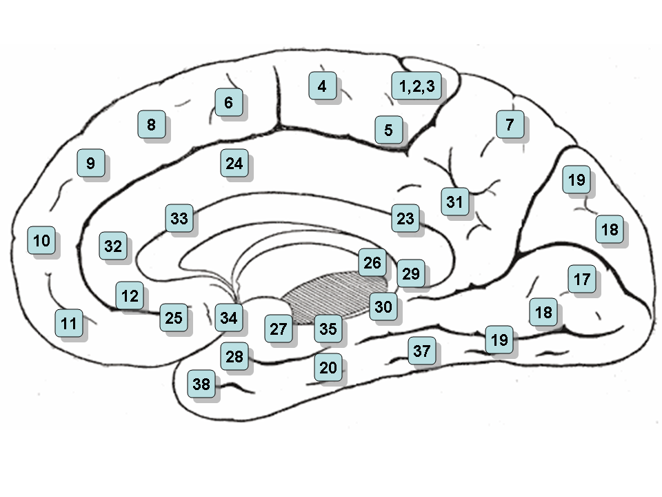

- **IMPORTANT:** All samples were derived from males of European ancestry.
- Library prep and sequencing:
  - Illumina TruSeq RNA Sample Prep Kit
  - polyA selection
  - 101-bp paired end on Illumina HiSeq 2000
  - Alignment performed as part of recount2.
    - Aligned to hg38 using Rail-RNA.
    - Gene and exon counts compiled by Rail-RAN using Gencode v25 annotation.

| sample_id | Source | Condition | Age_at_death | PMI | RIN | Sex | Motor_onset | Disease_duration | Dementia | Braak_score | Lewy_Body_pathology | ApoE | Cause_of_death |
| --- | --- | --- | --- | --- | --- | --- | --- | --- | --- | --- | --- | --- | --- |
| C_0002 | BSHRI | Control | 73 | 2 | 7.7 | Male |  |  | no | 3 | None | e3/e2 | Acute myocardial infarction |
| C_0003 | BSHRI | Control | 91 | 2 | 7.9 | Male |  |  | no | 2 | None | e3/e3 | Metastatic bladder cancer |
| C_0004 | BSHRI | Control | 82 | 2 | 8.6 | Male |  |  | no | 3 | None | e3/e3 | Cardiorespiratory arrest |
| C_0005 | BSHRI | Control | 97 | 2 | 9.1 | Male |  |  | no | 3 | None | e3/e2 | Metastatic colon cancer |
| C_0006 | BSHRI | Control | 86 | 5 | 8.6 | Male |  |  | no | 1 | None | e3/e3 | Cardiac arrest |
| C_0008 | BSHRI | Control | 91 | 2 | 8.7 | Male |  |  | no | 4 | None | e4/e3 | End stage renal disease |
| C_0009 | BSHRI | Control | 81 | 3 | 6 | Male |  |  | no | 1 | None | e3/e3 | Cardiac and/or respiratory failure |
| C_0010 | BSHRI | Control | 79 | 2 | 8.4 | Male |  |  | no | 1 | None | e3/e3 | Cardiac and/or respiratory failure |
| C_0011 | BSHRI | Control | 63 | 2 | 6.5 | Male |  |  | no | 2 | None | e3/e3 | Acute intracerebral hemorrhage |
| C_0012 | HBTRC | Control | 66 | 19 | 7.1 | Male |  |  | no |  | None |  | Myocardial infarction |

[output cut: 63 more lines]

## 3.1 Sample demographics - discrete variables

- **Note:** there are some individuals with both PD and dementia. For downstream analyses, these should be separated into their own group (PDD) to mirror our experimental set-up.

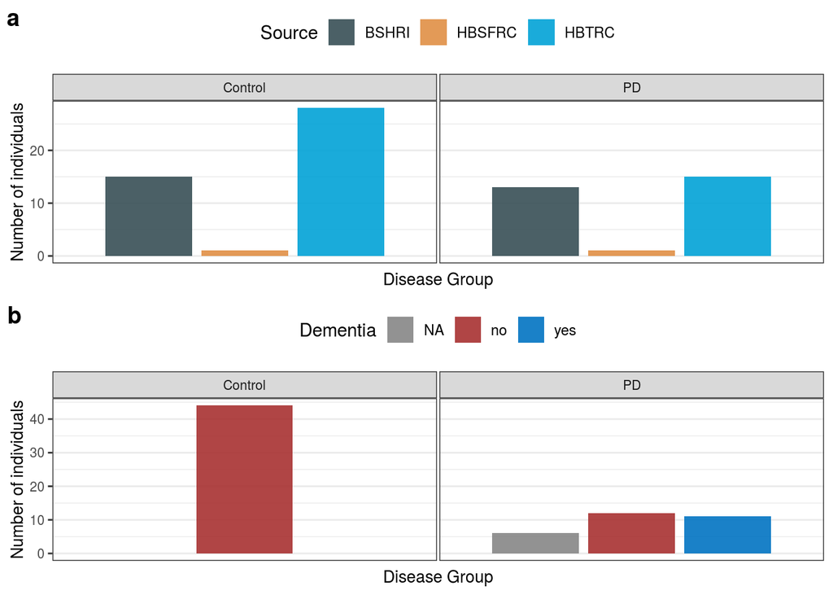

  (#fig:sample Dementia)Number of individuals (a) from each brain bank and (b) with dementia across disease groups.

## 3.2 Sample demographics - numeric variables

- Individuals with PD and a "yes" in the sample info were assigned to the PDD group in the newly created "Disease_group" column.
- Individuals with PD and "NA" in the "Dementia" column were assigned to the PD group in the newly created "Disease_group" column.
- Worth noting that some of the numeric variables are not complete for all samples.
  - Only 11 samples with motor onset
  - 9 samples without Braak score
  - 10 PD/PDD samples without disease duration.

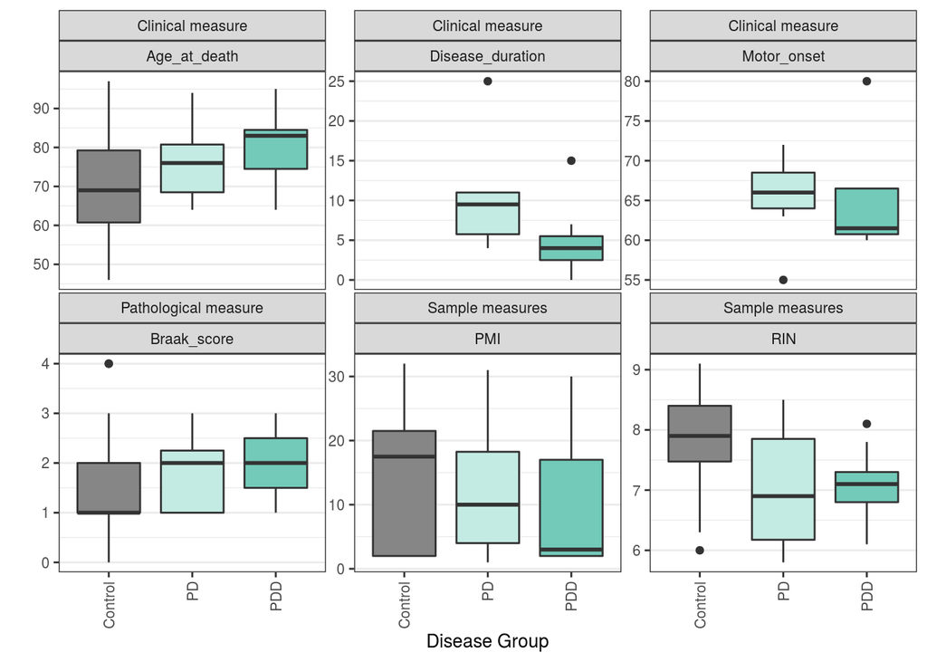

    (#fig:sample demographics)Plots of clinical, pathological and sample measures across disease groups.

### 3.2.1 Kruskal-Wallis

| test_variable | statistic | p.value | parameter | method |
| --- | --- | --- | --- | --- |
| RIN | 15.2777754 | 0.0004813636 | 2 | Kruskal-Wallis rank sum test |
| Braak_score | 8.6426573 | 0.0132822244 | 2 | Kruskal-Wallis rank sum test |
| Age_at_death | 7.4658800 | 0.0239224010 | 2 | Kruskal-Wallis rank sum test |
| Motor_onset | 0.5740378 | 0.4486588351 | 1 | Kruskal-Wallis rank sum test |
| PMI | 1.1951843 | 0.5501346823 | 2 | Kruskal-Wallis rank sum test |
| Disease_duration | 0.0827696 | 0.7735786410 | 1 | Kruskal-Wallis rank sum test |

### 3.2.2 Post-hoc pairwise wilcox tests with FDR correction

| test_variable | group1 | group2 | p.value |
| --- | --- | --- | --- |
| Age_at_death | PD | Control | 0.0989180619491879 |
| Age_at_death | PDD | Control | 0.0617206685635602 |
| Age_at_death | PDD | PD | 0.269689072389552 |
| Braak_score | PD | Control | 0.0362297607993667 |
| Braak_score | PDD | Control | 0.0362297607993667 |
| Braak_score | PDD | PD | 0.853094960389998 |
| RIN | PD | Control | 0.00333521911970183 |
| RIN | PDD | Control | 0.00333521911970183 |
| RIN | PDD | PD | 0.752217196137075 |

# 4 Deconvolution

- Deconvolution of SRP058181, using our own snRNA-seq. See report: SRP058181_deconvolution.html.

## 4.1 Summary

# 5 Post-quantification QC

For details, see: SRP058181_post_quant_QC.html

# 6 Leafcutter

- To determine appropriate covariate-correction, ran PCA with different correction methods applied to expression data. For details, see: SRP058181_post_correction_PCA.html
- Differential splicing performed with two different covariate correction strategies:
  - AoD & RIN
  - AoD, RIN, PMI and cell-type proportions
  - For full details, see: SRP058181_leafcutter.html

# 7 Replication analyses

- For details, refer to: cluster_validation_btwn_datasets.html
  - Layers of replication:
    1. At level of junctions
    2. At level of clusters
    3. At level of differential splicing